# mod_2_mcspadden_diana

Diana McSpadden

2/12/2021

# Module 2 Homework

## H. Diana McSpadden (hdm5s)

You will complete exercises 9, 14, and 15 at the end of Chapter 3 of your textbook.

```r
library(ggplot2)
library(tidyverse)
library(plotly)
library(scales)
library("GGally")
library(ISLR)
library(gridExtra)
library(broom)
```

# 9. This question involves the use of multiple linear regression on the Auto data set.

```r
head(Auto)
```

```
#>   mpg cylinders displacement horsepower weight acceleration year origin
#> 1  18         8          307        130   3504         12.0   70      1
#> 2  15         8          350        165   3693         11.5   70      1
#> 3  18         8          318        150   3436         11.0   70      1
#> 4  16         8          304        150   3433         12.0   70      1
#> 5  17         8          302        140   3449         10.5   70      1
#> 6  15         8          429        198   4341         10.0   70      1
#>                        name
#> 1 chevrolet chevelle malibu
#> 2         buick skylark 320
#> 3        plymouth satellite
#> 4             amc rebel sst
#> 5               ford torino
#> 6          ford galaxie 500
```

```r
#view(Auto)
```

## (a) Produce a scatterplot matrix which includes all of the variables in the data set.

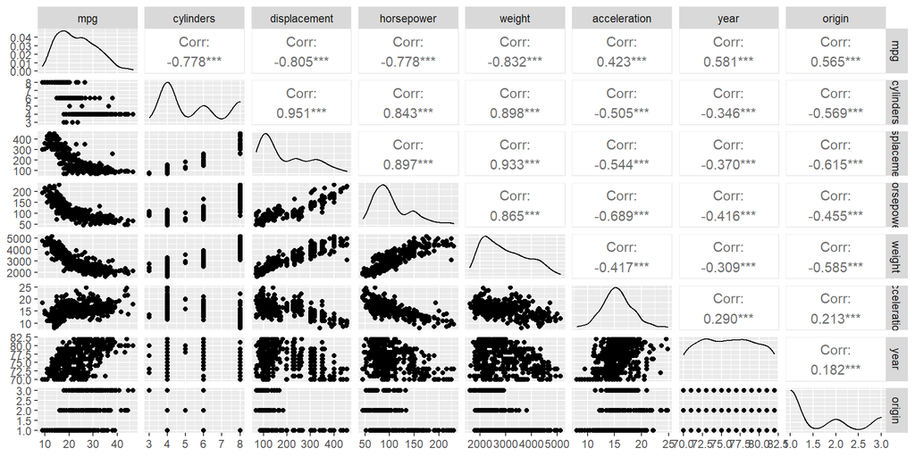

```r
ggpairs(Auto[-9], lower = list(continuous = "points", combo = "dot_no_facet"), progress = F)
```

## (b) Compute the matrix of correlations between the variables …

using the function cor(). You will need to exclude the name variable, cor() which is qualitative.

```r
cor(Auto[,-9])
```

```
#>                     mpg  cylinders displacement horsepower     weight
#> mpg           1.0000000 -0.7776175   -0.8051269 -0.7784268 -0.8322442
#> cylinders    -0.7776175  1.0000000    0.9508233  0.8429834  0.8975273
#> displacement -0.8051269  0.9508233    1.0000000  0.8972570  0.9329944
#> horsepower   -0.7784268  0.8429834    0.8972570  1.0000000  0.8645377
#> weight       -0.8322442  0.8975273    0.9329944  0.8645377  1.0000000
#> acceleration  0.4233285 -0.5046834   -0.5438005 -0.6891955 -0.4168392
#> year          0.5805410 -0.3456474   -0.3698552 -0.4163615 -0.3091199
#> origin        0.5652088 -0.5689316   -0.6145351 -0.4551715 -0.5850054
#>              acceleration       year     origin
#> mpg             0.4233285  0.5805410  0.5652088
#> cylinders      -0.5046834 -0.3456474 -0.5689316
#> displacement   -0.5438005 -0.3698552 -0.6145351
#> horsepower     -0.6891955 -0.4163615 -0.4551715
#> weight         -0.4168392 -0.3091199 -0.5850054
#> acceleration    1.0000000  0.2903161  0.2127458
#> year            0.2903161  1.0000000  0.1815277
#> origin          0.2127458  0.1815277  1.0000000
```

## (c) Use the lm() function to perform a multiple linear regression …

with mpg as the response and all other variables except name as the predictors. Use the summary() function to print the results. Comment on the output.

```r
lm.model.all  = lm(mpg~.-name, data=Auto)
summary(lm.model.all)
```

```
#>
#> Call:
#> lm(formula = mpg ~ . - name, data = Auto)
#>
#> Residuals:
#>     Min      1Q  Median      3Q     Max
#> -9.5903 -2.1565 -0.1169  1.8690 13.0604
#>
#> Coefficients:
#>                Estimate Std. Error t value Pr(>|t|)
#> (Intercept)  -17.218435   4.644294  -3.707  0.00024 ***
#> cylinders     -0.493376   0.323282  -1.526  0.12780
#> displacement   0.019896   0.007515   2.647  0.00844 **
#> horsepower    -0.016951   0.013787  -1.230  0.21963
#> weight        -0.006474   0.000652  -9.929  < 2e-16 ***
#> acceleration   0.080576   0.098845   0.815  0.41548
#> year           0.750773   0.050973  14.729  < 2e-16 ***
#> origin         1.426141   0.278136   5.127 4.67e-07 ***
#> ---
#> Signif. codes:  0 '***' 0.001 '**' 0.01 '*' 0.05 '.' 0.1 ' ' 1
#>
#> Residual standard error: 3.328 on 384 degrees of freedom
#> Multiple R-squared:  0.8215, Adjusted R-squared:  0.8182
#> F-statistic: 252.4 on 7 and 384 DF,  p-value: < 2.2e-16
```

**Is there a relationship between the predictors and the response?**

Yes, there does appear to be a relationship between the predictors and response. The model is significant with an F-statistic of 252.4, and significant p-value. The model’s R2 is 0.8215 indicating that ~82% of the variability in mpg can be explained by the model.

**Which predictors appear to have a statistically significant relationship to the response?**

In an additive model of mpg vs cylinders, displacement, horsepower, weight, acceleration, year, and origin I notice the following from the model summary: 1. cylinders, horsepower, and acceleration are not statistically significant 2. displacement, weight, year, and origin are statistically significant.

**What does the coefficient for the year variable suggest?**

The coefficient for year suggests that when the other predictors are held constant, for cars represented in the sample (years 1970 - 1982), a car that is one year newer than another car produces an increase of .75 in the miles per gallon efficiency of a car.

## (d) Use the plot() function to produce diagnostic plots …

of the linear regression fit. Comment on any problems you see with the fit.

Do the residual plots suggest any unusually large outliers?

Does the leverage plot identify any observations with unusually high leverage?

**Useful Plotting Functions** Here are useful plotting functions referenced from Module 2 lab.

I have commented the code to document parts I researched.

```r
# From Module 2 Lab, the Residual Plot
scatterall <- function(lm.fit){
  lm.fit %>%
  ggplot(aes(.fitted, .resid)) + geom_point() +
    stat_smooth(method="loess") +
    geom_hline(yintercept=0, col="red", linetype="dashed") +
    labs(x="Fitted values", y="Residuals", title="Residual vs Fitted Plot") +
    theme_bw()
}


# From Module 2 lab and Tidyverse website, the qq plot # https://ggplot2.tidyverse.org/reference/geom_qq.html
q_q <- function(lm.model.fit){
  lm.model.fit %>% augment() %>% # augment adds the standardized residuals that we need
  ggplot(aes(sample=.std.resid)) +
  stat_qq() + stat_qq_line() +
  labs(x="Theoretical Quantiles", y="Sample Quantiles", title="Q-Q Plot") +
  theme_bw()
}

# From Module 2 lab the residual vs. leverage
# https://rpubs.com/therimalaya/43190
resVlev <- function(lm.model.fit){
  lm.model.fit %>% augment() %>% rownames_to_column() %>% # augment gives us residuals and hat values
  ggplot(aes(.hat,.std.resid, label=rowname)) + # hat values and residuals
    geom_point(aes(size=.cooksd), na.rm=TRUE) +
    stat_smooth(method="loess", na.rm=TRUE) +
    scale_x_continuous(name="Leverage") +
    scale_y_continuous(name="Standardized Residuals") +
    ggtitle("Residual vs Leverage Plot") +
    theme_bw() + theme(legend.position="bottom")
}

# Cooks Distance For Influential Data Points
#A general rule of thumb is that any point with a Cook’s Distance over 4/n (where n is the total number of data points) is considered to be an outlier.
cookVals <- function(lm.fit) {
  lm.fit %>% augment() %>%
  ggplot(aes(seq_along(.cooksd), .cooksd))+
  geom_bar(stat="identity", position="identity") +
  labs(x="Obs. Number", y=TeX("Cook's distance"),
       title="Cook's Distance - Influential Data Points") + theme_bw()
}

# plot the hat values by their sequence in the observations ??????
hatVals <- lm.model.all %>% augment() %>%
  ggplot(aes(seq_along(.hat), .hat))+
  geom_bar(stat="identity", position="identity") +
  labs(x="Obs. Number", y=TeX("Hat values"),
       title="Hat values") + theme_bw()
```

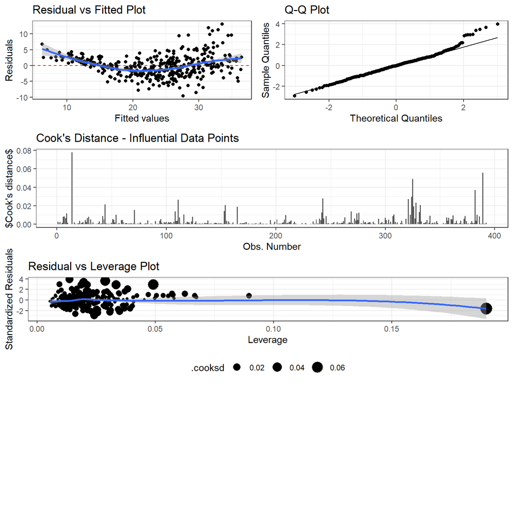

```r
grid.arrange(scatterall(lm.model.all), q_q(lm.model.all), cookVals(lm.model.all), resVlev(lm.model.all),
             widths=c(1,1),
             layout_matrix = rbind(c(1, 2),
                                   c(3, 3),
                                   c(4, 4),
                                   c(5,5)))
```

```r
print(paste("High Cooks Value:", 4/nrow(Auto)))
```

```
#> [1] "High Cooks Value: 0.0102040816326531"
```

```r
which.max(hatvalues(lm.model.all))
```

```
#> 14
#> 14
```

## (e) Use the * and : symbols …

to fit linear regression models with interaction effects. Do any interactions appear to be statistically significant?

**Comments** Weight and cylinders make the most sense to me as possibly have an interaction effect. As cyclinders are added to the engine, I would imagine that additional weight would have an even great impact on mpg. I will try a model with an interaction effect between cylinders and weight.

I ran this model a few times, trying to tweak it for better results. The first time I ran with all predictors + an interaction between weight and cyclinders. The interaction was statistically significant (p-value < 2e-16); however, the acceleration predictor was insignificant. The Adjusted R2 value was .85 (an increase from the full model without interaction with an Adjusted R2 of .82).

I then removed acceleration from the model; however, the R2 did not improve.

I then added another interaction of year * cylinders, due to thinking that new technology the number of cylinders may have had a different effect on mpg. This increased the Adjusted R2 to .86. Displacement was no longer significant in this model.

```r
#lm.model.int.w.c = lm(mpg~.-name+(weight*cylinders), data=Auto)

#lm.model.int.w.c = lm(mpg~.-name-acceleration+(weight*cylinders), data=Auto)

lm.model.int.w.c = lm(mpg~.-name-acceleration+(weight*cylinders)+(year*cylinders), data=Auto)
summary(lm.model.int.w.c)
```

```
#>
#> Call:
#> lm(formula = mpg ~ . - name - acceleration + (weight * cylinders) +
#>     (year * cylinders), data = Auto)
#>
#> Residuals:
#>     Min      1Q  Median      3Q     Max
#> -9.7409 -1.6013 -0.1702  1.3054 12.1436
#>
#> Coefficients:
#>                    Estimate Std. Error t value Pr(>|t|)
#> (Intercept)      -5.181e+01  1.216e+01  -4.260 2.58e-05 ***
#> cylinders         7.305e+00  2.348e+00   3.111  0.00200 **
#> displacement      8.673e-03  6.670e-03   1.300  0.19429
#> horsepower       -4.960e-02  9.819e-03  -5.052 6.78e-07 ***
#> weight           -1.358e-02  1.052e-03 -12.901  < 2e-16 ***
#> year              1.544e+00  1.485e-01  10.396  < 2e-16 ***
#> origin            8.294e-01  2.527e-01   3.282  0.00112 **
#> cylinders:weight  1.354e-03  1.622e-04   8.349 1.27e-15 ***
#> cylinders:year   -1.528e-01  2.824e-02  -5.412 1.10e-07 ***
#> ---
#> Signif. codes:  0 '***' 0.001 '**' 0.01 '*' 0.05 '.' 0.1 ' ' 1
#>
#> Residual standard error: 2.918 on 383 degrees of freedom
#> Multiple R-squared:  0.8631, Adjusted R-squared:  0.8603
#> F-statistic: 301.9 on 8 and 383 DF,  p-value: < 2.2e-16
```

## (f) Try a few different transformations of the variables, such as log(X), and sqrt(X), and X^2

Comment on your findings.

**Process**

From the correlation scatter plots it appears there is a non-linear relationship between: * mpg and weight * mpg and displacement * and mpg and horsepower.

I removed displacement and accelerations from the full model because they were no longer significant after the additive terms were included.

To correct for the non-linear residuals, I will attempt some transformations on the predictor variables. From the residual plot it appears a quadratic relationship exists. Individually, I added square terms for both weight and horsepower.

This results in a R Adjusted of .87 and even more importantly, the non-linear residual plot issue has been corrected. However, with the quadratic terms for weight and horsepower, we now have 3 high leverage points.

```r
#lm.model.int.trans = lm(mpg~.-name-acceleration+(weight*cylinders)+(year*cylinders), data=Auto)

lm.model.int.trans = lm(mpg~.-name-acceleration-displacement+(year*cylinders)+I(weight^2)+I(horsepower^2), data=Auto)

summary(lm.model.int.trans)
```

```
#>
#> Call:
#> lm(formula = mpg ~ . - name - acceleration - displacement + (year *
#>     cylinders) + I(weight^2) + I(horsepower^2), data = Auto)
#>
#> Residuals:
#>     Min      1Q  Median      3Q     Max
#> -7.8636 -1.6166 -0.0594  1.3286 11.7423
#>
#> Coefficients:
#>                   Estimate Std. Error t value Pr(>|t|)
#> (Intercept)     -4.686e+01  1.184e+01  -3.957 9.05e-05 ***
#> cylinders        9.690e+00  2.167e+00   4.473 1.02e-05 ***
#> horsepower      -1.423e-01  2.974e-02  -4.786 2.43e-06 ***
#> weight          -1.480e-02  1.806e-03  -8.198 3.71e-15 ***
#> year             1.408e+00  1.487e-01   9.469  < 2e-16 ***
#> origin           7.619e-01  2.354e-01   3.237 0.001313 **
#> I(weight^2)      1.522e-06  2.640e-07   5.766 1.67e-08 ***
#> I(horsepower^2)  3.967e-04  1.059e-04   3.747 0.000206 ***
#> cylinders:year  -1.244e-01  2.823e-02  -4.408 1.36e-05 ***
#> ---
#> Signif. codes:  0 '***' 0.001 '**' 0.01 '*' 0.05 '.' 0.1 ' ' 1
#>
#> Residual standard error: 2.848 on 383 degrees of freedom
#> Multiple R-squared:  0.8695, Adjusted R-squared:  0.8668
#> F-statistic: 319.1 on 8 and 383 DF,  p-value: < 2.2e-16
```

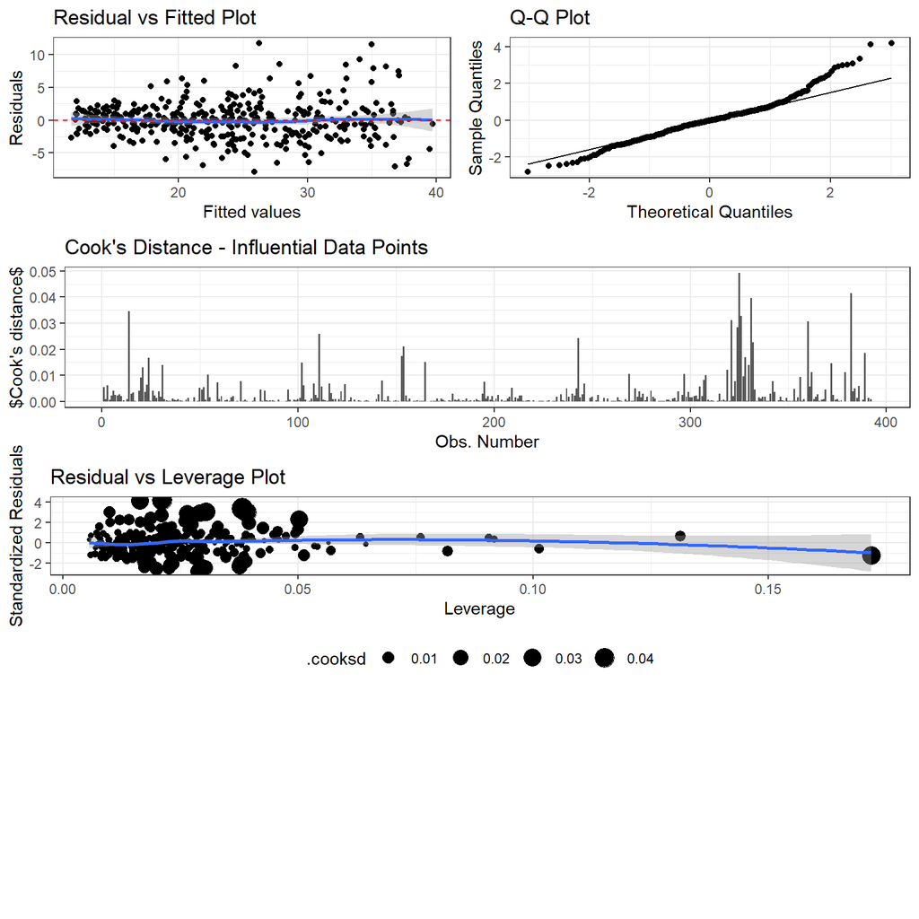

```r
grid.arrange(scatterall(lm.model.int.trans), q_q(lm.model.int.trans), cookVals(lm.model.int.trans), resVlev(lm.model.int.trans),
             widths=c(1,1),
             layout_matrix = rbind(c(1, 2),
                                   c(3, 3),
                                   c(4, 4),
                                   c(5,5)))
```

# 14 This problem focuses on the collinearity problem.

## (a) Perform the following commands in R:

set .seed (1)  
x1=runif (100)  
x2 =0.5* x1+rnorm (100) /10  
y=2+2* x1 +0.3* x2+rnorm (100)

The last line corresponds to creating a linear model in which y is a function of x1 and x2. Write out the form of the linear model. What are the regression coefficients?

```r
set.seed (1)
x1=runif(100) #Generates random compositions with a uniform distribution on the (rcomp) simplex.
x2 =0.5* x1+rnorm(100) /10
y=2+2* x1 +0.3* x2+rnorm(100)
```

## (b) What is the correlation between x1 and x2?

Create a scatter plot displaying the relationship between the variables.

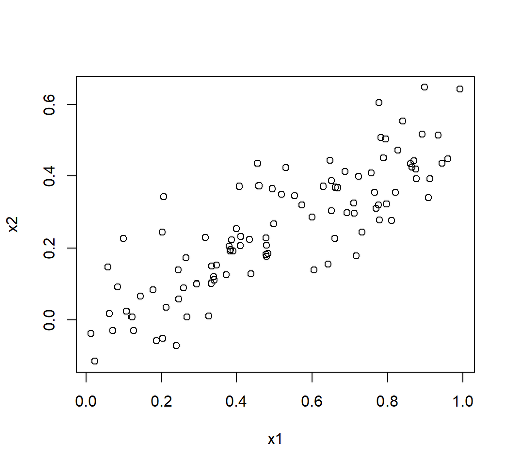

```r
plot(x1,x2)
```

**Answer q14b:** There appears to be a positive linear relationship between x1 and x2.

## (c) Using this data, fit a least squares regression …

to predict y using x1 and x2.

```r
lm.x1.x2 = lm(y~x1+x2)
summary(lm.x1.x2)
```

```
#>
#> Call:
#> lm(formula = y ~ x1 + x2)
#>
#> Residuals:
#>     Min      1Q  Median      3Q     Max
#> -2.8311 -0.7273 -0.0537  0.6338  2.3359
#>
#> Coefficients:
#>             Estimate Std. Error t value Pr(>|t|)
#> (Intercept)   2.1305     0.2319   9.188 7.61e-15 ***
#> x1            1.4396     0.7212   1.996   0.0487 *
#> x2            1.0097     1.1337   0.891   0.3754
#> ---
#> Signif. codes:  0 '***' 0.001 '**' 0.01 '*' 0.05 '.' 0.1 ' ' 1
#>
#> Residual standard error: 1.056 on 97 degrees of freedom
#> Multiple R-squared:  0.2088, Adjusted R-squared:  0.1925
#> F-statistic:  12.8 on 2 and 97 DF,  p-value: 1.164e-05
```

```r
confint(lm.x1.x2)
```

```
#>                    2.5 %   97.5 %
#> (Intercept)  1.670278673 2.590721
#> x1           0.008213776 2.870897
#> x2          -1.240451256 3.259800
```

### Describe the results obtained. What are ˆβ0, ˆβ1, and ˆβ2? How do these relate to the true β0, β1, and β2?

**Answer q14b**: x1 is significant, but x2 is not. The complete model is significant (F-statistic of 12.8 and significant p-value).

- ˆβ0: 2.13
- ˆβ1: 1.44
- ˆβ2: 1.01

The estimated coefficients represent the values that produce the least square residuals fitting y with x1 and x2 in the model
$$y = \hat{B0} + \hat{B1}x1 + \hat{B2}x2$$

### Can you reject the null hypothesis H0 : β1 = 0?

**Answer q14b**: Yes, we can reject the null hypothesis. The p-value for the predictor is significant, and the 95% confidence interval does not contain 0.

### How about the null hypothesis H0 : β2 = 0?

## (d) Now fit a least squares regression to predict y using only x1.

Comment on your results. Can you reject the null hypothesis H0 : β1 = 0? (e) Now fit a least squares regression to predict y using only x2. Comment on your results. Can you reject the null hypothesis H0 : β1 = 0? (f) Do the results obtained in (c)–(e) contradict each other? Explain your answer. (g) Now suppose we obtain one additional observation, which was unfortunately mismeasured. > x1=c(x1 , 0.1) > x2=c(x2 , 0.8) > y=c(y,6) Re-fit the linear models from (c) to (e) using this new data. What effect does this new observation have on the each of the models? In each model, is this observation an outlier? A high-leverage point? Both? Explain your answers.

# 15